# Научная презентация 7

Дисциплина:Операционные системы

Алехин Давид Андреевич

Российский университет дружбы народов, Москва, Россия

Математический институт имени Никольского, Москва, Россия

# Информация

## Докладчик

- Алехин Давид Андреевич
- Студент
- Студент НММбд-01-24
- Российский университет дружбы народов
- 1132246830@pfur.ru
- https://github.com/trustdef

[figure not shown]

# Элементы презентации

## Актуальность

- Важно уметь работать с файловой системой.

## Цели и задачи

- Приобретение практических навыков взаимодействия пользователя с системой по- средством командной строки.

## Материалы и методы

- fedora-linux

## Содержание исследования

Выполняю примеры 1 2 3 4 (рис. [-@fig:001], [-@fig:002], [-@fig:003], [-@fig:004]).

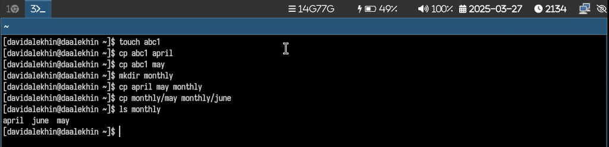

примеры

## Содержание исследования

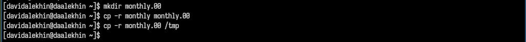

примеры

## Содержание исследования

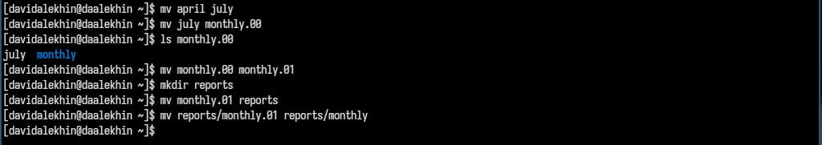

примеры

## Содержание исследования

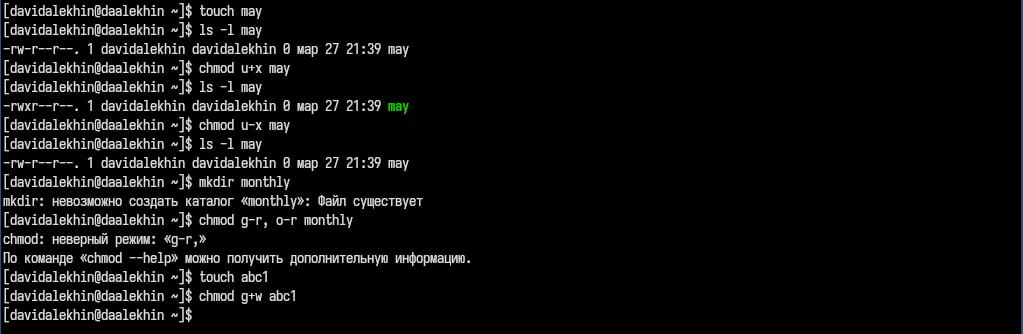

примеры

## Содержание исследования

Выполняю 2.1 2.2 2.3 2.4 (рис. [-@fig:005]).

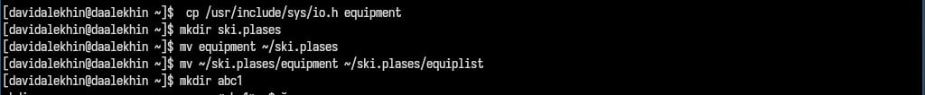

2.1-2.4

## Содержание исследования

Bыполняю 2.5 (рис. [-@fig:006]).

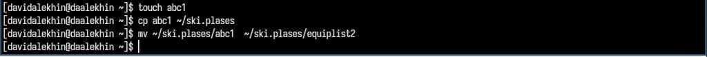

2.5

## Содержание исследования

выполняю 2.6 2.7 2.8 (рис. [-@fig:007]).

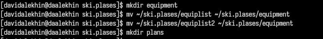

2.6-2.8

## Содержание исследования

3 чтобы задать приведённые права доступа нужны следующие опции: 3.1 111.110.010 3.2 111.100.100 3.3 010.110.010 3.4 011.011.010

Bыполняю приведённые ниже упражнения пункта 4 (рис. [-@fig:008], [-@fig:009], [-@fig:010], [-@fig:011]).

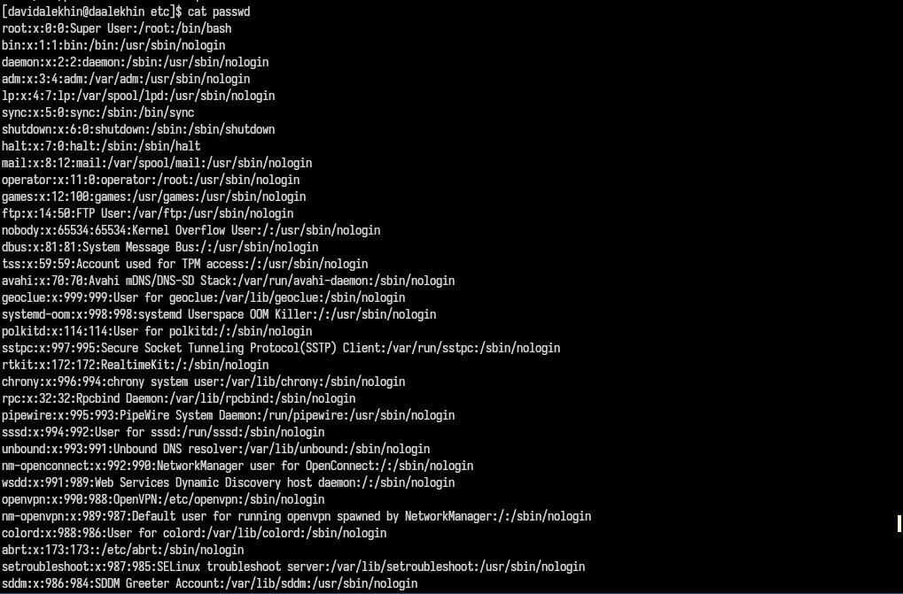

4

## Содержание исследования

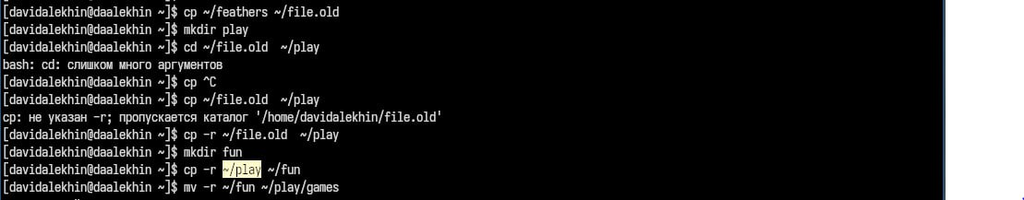

4

## Содержание исследования

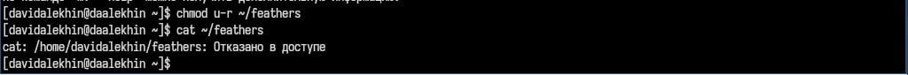

4

## Содержание исследования

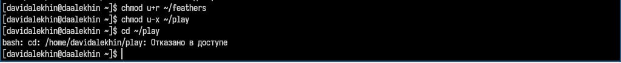

4

## Содержание исследования

Выполняю пункт 5:

Команда mount используется для монтирования файловой системы. Она принимает два параметра: файл устройства, соответствующий диску или разделу, на котором расположена файловая система, и имя каталога, к которому будет монтироваться система. Например, чтобы смонтировать дискету MS-DOS, нужно выполнить команду:

mount -t msdos /dev/fd0 /floppy

Команда fsck служит для проверки целостности и работоспособности файловой системы. Большинство систем сконфигурировано так, что команда fsck запускается автоматически при загрузке системы. Например, чтобы проверить диск /dev/sda6, нужно выполнить команду:

sudo fsck -a /dev/sda6

## Содержание исследования

Команда mkfs позволяет создать файловую систему Linux. Например, чтобы отформатировать раздел с файловой системой ext4, можно выполнить команды:

mkfs.ext4 /dev/sdb3

Команда kill используется для завершения процессов. Например, чтобы корректно завершить процесс с PID 98989, нужно выполнить команду:

kill -TERM 98989

## Результаты

Я выполнил основную цель работы: Ознакомление с файловой системой Linux, её структурой, именами и содержанием каталогов. Приобретение практических навыков по применению команд для работы с файлами и каталогами, по управлению процессами (и работами), по проверке исполь- зования диска и обслуживанию файловой системы.

## Итоговый слайд

В теории, теория и практика неразделимы. На практике это не так. Yoggi Berra